# Bibliométrie

Eric Marcon

12 January 2021

Abstract

Utilisation de Google Scholar et de Scopus avec R pour analyser les publications d’une structure ou d’un auteur.

# 1 Google Scholar

Le package *scholar* permet d’accéder à l’API de Google Scholar. L’objectif est d’analyser la production d’un auteur (ou d’une structure) disposant d’un identifiant, donc d’une page, Google Scholar.

Le paramètre de base est l’identifiant de l’auteur :

```r
# AuthorID <- "4iLBmbUAAAAJ" # Eric Marcon
AuthorID <- "8XqZyDUAAAAJ" # UMR EcoFoG
```

La vignette du package fournit la majorité du code utile.

```r
vignette(topic = "scholar", package = "scholar")
```

## 1.1 Information sur l’auteur

La fonction `get_profile` retourne une liste avec les informations sur l’auteur.

```r
library("scholar")
get_profile(AuthorID)
```

```
## $id
## [1] "8XqZyDUAAAAJ"
##
## $name
## [1] "UMR EcoFoG"
##
## $affiliation
## [1] "Research Unit"
##
## $total_cites
## [1] 38736
##
## $h_index
## [1] 96
##
## $i10_index
## [1] 501
##
## $fields
## [1] "verified email at ecofog.gf - homepage"
##
## $homepage
## [1] "http://www.ecofog.gf/"
##
## $coauthors
##  [1] "Bruno Herault"        "Chris Baraloto"
##  [3] "JACQUES BEAUCHENE"    "Lilian Blanc"
##  [5] "Vivien Rossi"         "Didier Stien"
##  [7] "Céline Leroy"         "Eric Marcon"
##  [9] "C. E. Timothy Paine"  "Ivan Scotti"
## [11] "Fabien Hubert Wagner" "Plínio Sist"
## [13] "Bruno Clair"          "Clément Stahl"
## [15] "Heidy Schimann"       "meriem FOURNIER"
## [17] "Claire Fortunel"      "Julien Ruelle"
## [19] "Olivier Roux"         "Nadine Amusant"
```

## 1.2 Liste des publications

La fonction `get_publications` retourne un dataframe contenant toutes les publications. Les colonnes contiennent le titre, la liste des auteurs (séparés par des virgules), le nom du journal, la pagination (sous la forme *Volume (numéro), pages*), le nombre de citations et les années correspondantes (sous la forme de vecteurs), et deux identifiants internes de la publication (`cid` et `pubid`).

```r
Publications <- get_publications(AuthorID)
colnames(Publications)
```

```
## [1] "title"   "author"  "journal" "number"
## [5] "cites"   "year"    "cid"     "pubid"
```

## 1.3 Citations par année

Evolution du nombre de citations d’un auteur :

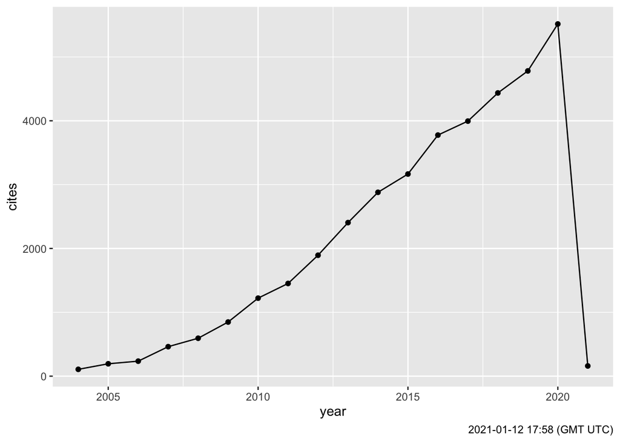

```r
library("ggplot2")

get_citation_history(AuthorID) %>%
  ggplot(aes(x = year, y = cites)) +
    geom_line() +
    geom_point() +
    labs(caption= format(Sys.time(), "%Y-%m-%d %H:%M (GMT %Z)"))
```

Suivi d’un article en particulier (le plus cité: les articles sont classés par ordre décroissant du nombre de citations) :

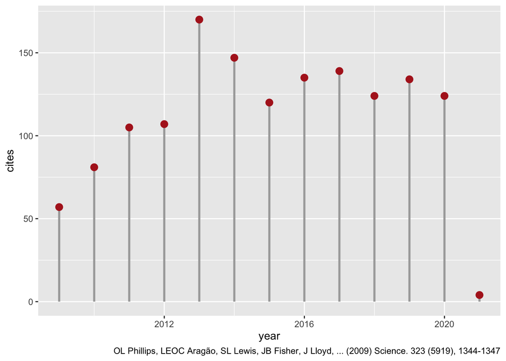

```r
NumArticle <- 1
Reference <- with(Publications[NumArticle, ],
  paste(author, " (", year, ") ", journal, ". ", number, sep=""))
get_article_cite_history(AuthorID, Publications$pubid[NumArticle]) %>%
  ggplot(aes(year, cites)) +
    geom_segment(aes(xend = year, yend = 0), size=1, color='darkgrey') +
    geom_point(size=3, color='firebrick') +
    labs(caption = Reference)
```

## 1.4 Réseau d’auteurs

`get_coauthors` retourne un dataframe contenant les coauteurs déclarés par l’auteur sur sa page et leurs coauteurs. La profondeur `n_deep` du graphe permet d’augmenter le nombre de niveaux de coauteurs mais ne peut pas être mise à 0 pour obtenir seulement les coauteurs directs. Les valeurs par défaut sont 5 coauteurs et une profondeur de 1.

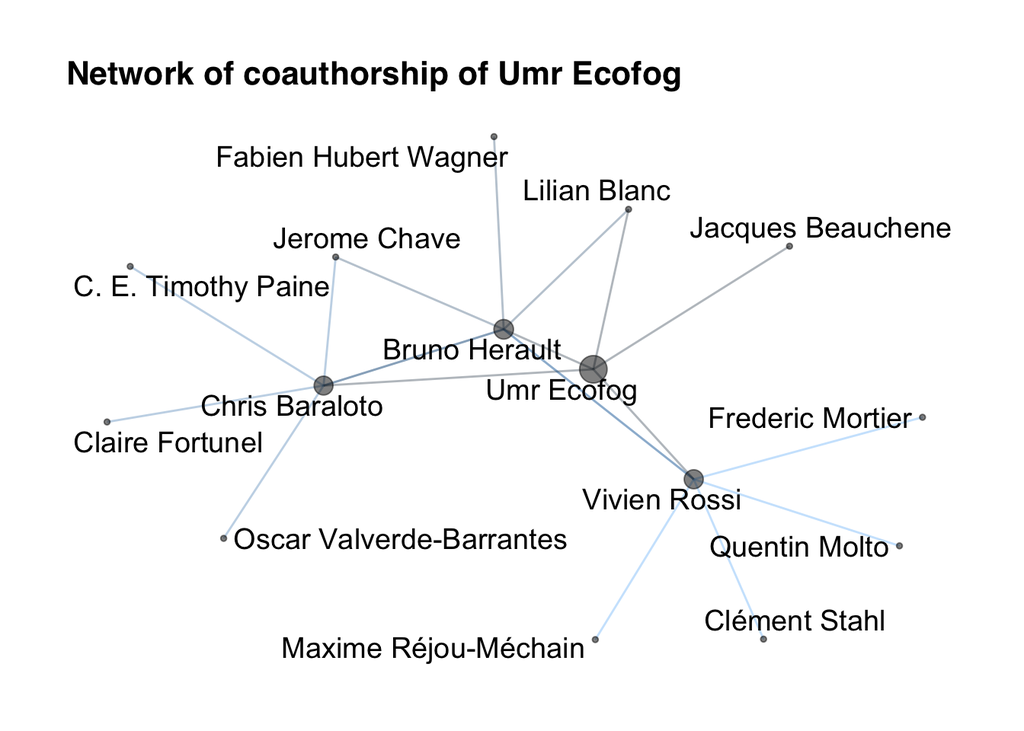

```r
get_coauthors(AuthorID, n_coauthors = 5, n_deep=1) %>%
  # Bug in get_coauthors
  filter(substr(coauthors, start = 1, stop = 8) != "Sort By ") %>%
  plot_coauthors
```

Les coauteurs réels, définis par le nombre de publications écrites en commun, sont à rechercher dans le tableau des publications.

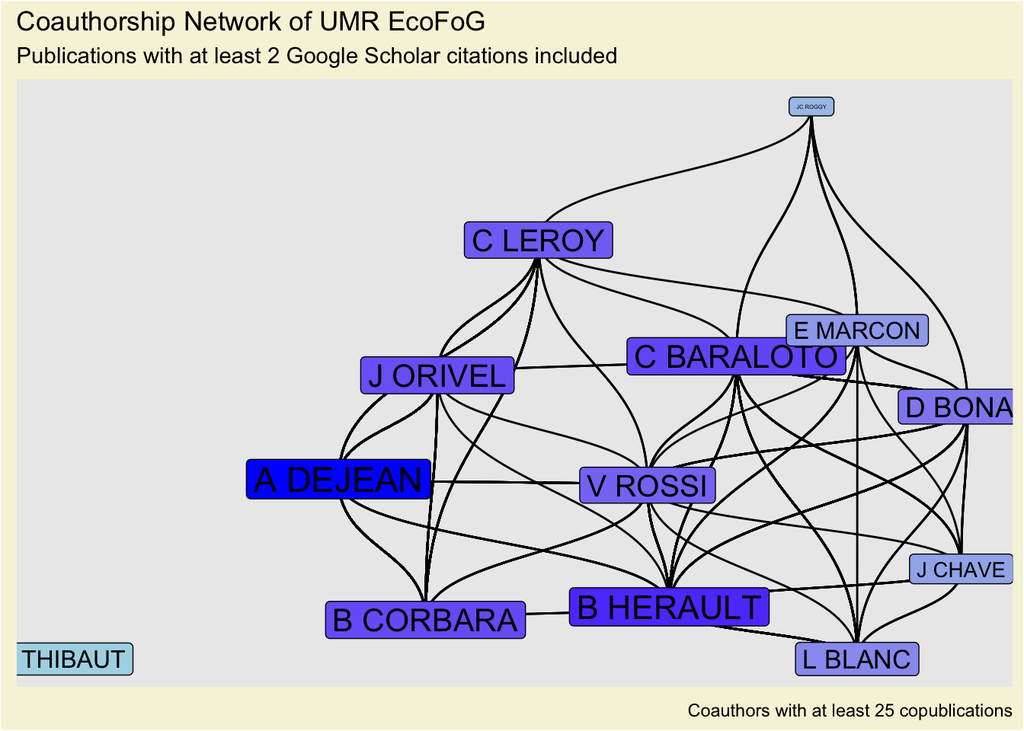

```r
### Paramètres
# Augmenter pour limiter le nombre de coauteurs affichés
MinCopublications <- 25
# Eliminer les documents non cités (mémoires, artefacts)
MinCitations <- 2
# Eliminer les coauteurs les moins productifs
MaxCoauteurs <- 100

library("magrittr")
# Vecteur des coauteurs de publications, sans accents
get_publications(AuthorID) %>%
  dplyr::filter(cites >= MinCitations) %>%
  mutate(AuthorsASCII=iconv(author, from="UTF-8", to="ASCII//TRANSLIT")) %$%
  AuthorsASCII %>%
  # Suppression des accents transformés en ' sur MacOS
  str_replace("'", "") ->
  AuthorsASCII
# Auteurs uniques
AuthorsASCII %>%
  paste(collapse=", ") %>%
  str_split(pattern=", ") %>%
  unlist %>%
  # Uniformisation de la casse
  str_to_upper() %>%
  unique ->
  UniqueAuthors
# Elimination de ... (= et al.)
UniqueAuthors <- UniqueAuthors[UniqueAuthors != "..."]
# Matrice d'autorat: une ligne par article, auteurs en colonnes, valeurs logiques
PaperAuthoredBy <- sapply(UniqueAuthors, function(Author) str_detect(str_to_upper(AuthorsASCII), Author))
# Filtrage des auteurs
tibble(Author=UniqueAuthors, NbPapers=colSums(PaperAuthoredBy)) %>%
  filter(NbPapers >= MinCopublications) %>%
  arrange(desc(NbPapers)) %>%
  slice(1:MaxCoauteurs) ->
  NbPapersPerAuthor
# Recalcul de la matrice d'autorat réduite
PaperAuthoredBy <- sapply(NbPapersPerAuthor$Author,
                          function(Author) str_detect(str_to_upper(AuthorsASCII), Author))
# Matrice d'adjacence
adjacencyMatrix <- t(PaperAuthoredBy) %*% PaperAuthoredBy
# Graphe d'adjacence
# (https://paulvanderlaken.com/2017/10/31/network-visualization-with-igraph-and-ggraph/)
library("igraph")
g <- graph.adjacency(adjacencyMatrix, mode = "undirected", diag = FALSE)
V(g)$Degree <- degree(g, mode = 'in') # Nombre de liens
V(g)$Name <- NbPapersPerAuthor$Author # Etiquettes des noeuds
# Figure
library("ggraph")
ggraph(g, layout = "auto") +
  geom_edge_diagonal(alpha = 1, label_colour = "blue") +
  geom_node_label(aes(label = Name, size = log(Degree), fill = Degree)) +
  scale_fill_gradient(high = "blue", low = "lightblue") +
  theme(
    plot.background = element_rect(fill = "beige"),
    panel.border = element_blank(),
    panel.grid = element_blank(),
    legend.position = "none",
    axis.text = element_blank(),
    axis.title = element_blank(),
    axis.ticks = element_blank()) +
  labs(title = paste("Coauthorship Network of", get_profile(AuthorID)$name),
       subtitle = paste("Publications with at least", MinCitations, "Google Scholar citations included"),
       caption = paste("Coauthors with at least", MinCopublications, "copublications"))
```

Nombres de publications :

```r
knitr::kable(NbPapersPerAuthor, caption="Nombre de documents par auteur",
             longtable = FALSE, booktabs = TRUE) %>%
  kableExtra::kable_styling(bootstrap_options = "striped")
```

Table 1.1: Nombre de documents par auteur

| Author | NbPapers |
| --- | --- |
| A DEJEAN | 92 |
| B HERAULT | 86 |
| C BARALOTO | 83 |
| J ORIVEL | 55 |
| D BONAL | 48 |
| C LEROY | 37 |
| B CORBARA | 36 |
| L BLANC | 32 |
| V ROSSI | 32 |
| B THIBAUT | 30 |
| E MARCON | 28 |
| J CHAVE | 26 |
| JC ROGGY | 25 |

# 2 Scopus et Web of Science

Le package *bibliometrix* permet d’exploiter les données des bases de données commerciales majeures.

La vignette du package décrit l’ensemble de ses possibilités.

```r
vignette(topic = "bibliometrix-vignette", package = "bibliometrix")
```

## 2.1 Lecture des données

Voir la première partie de la vignette. Sur le site de Scopus (utilisé en exemple), sélectionner les références utiles et les exporter dans un fichier Bibtex. L’export doit contenir tous les champs, y compris le résumé et les documents cités.

Le fichier est ensuite lu et converti:

```r
library(bibliometrix)
# Fichier de données au format bibtex, exporté de Scopus
M <- convert2df("scopus.bib", dbsource="scopus", format="bibtex")
```

```
##
## Converting your scopus collection into a bibliographic dataframe
##
## Done!
##
##
## Generating affiliation field tag AU_UN from C1:  Done!
```

## 2.2 Analyses basiques

Les analyses de base sont retournées par la fonction `biblioAnalysis`. Le résultat est un objet de type `bibliometrix`. Les méthodes `summary` et `plot` renvoient tous les résultats à l’écran.

```r
k <- 5 # Nombre d'auteurs à afficher
BA <- biblioAnalysis(M)
summary(BA, k)
```

```
##
##
## MAIN INFORMATION ABOUT DATA
##
##  Timespan                              2001 : 2020
##  Sources (Journals, Books, etc)        299
##  Documents                             859
##  Average years from publication        8.12
##  Average citations per documents       32.73
##  Average citations per year per doc    3.632
##  References                            42751
##
## DOCUMENT TYPES
##  article               793
##  book chapter          3
##  conference paper      19
##  data paper            2
##  editorial             1
##  erratum               4
##  letter                4
##  note                  4
##  review                28
##  short survey          1
##
## DOCUMENT CONTENTS
##  Keywords Plus (ID)                    5239
##  Author's Keywords (DE)                2629
##
## AUTHORS
##  Authors                               5279
##  Author Appearances                    11438
##  Authors of single-authored documents  7
##  Authors of multi-authored documents   5272
##
## AUTHORS COLLABORATION
##  Single-authored documents             7
##  Documents per Author                  0.163
##  Authors per Document                  6.15
##  Co-Authors per Documents              13.3
##  Collaboration Index                   6.19
```

[output cut: 107 more lines]

```
##
##
## Most Relevant Keywords
##
##    Author Keywords (DE)      Articles Keywords-Plus (ID)     Articles
## 1       FRENCH GUIANA              93        FRENCH GUIANA        330
## 2       TROPICAL FOREST            31        ARTICLE              220
## 3       TROPICAL RAINFOREST        23        ANT                  174
## 4       FUNCTIONAL DIVERSITY       18        BIODIVERSITY         156
## 5       FUNCTIONAL TRAITS          17        ANIMALS              147
## 6       TENSION WOOD               17        TREE                 136
## 7       AMAZONIA                   16        ECOSYSTEM            135
## 8       AMAZON                     15        TROPICAL FOREST      135
## 9       BIODIVERSITY               15        ANIMAL               126
## 10      TROPICAL TREES             15        RAINFOREST           124
```

Pour les afficher séparément, il faut stocker le résultat dans une variable (qui est une liste) et appeler ensuite chacun de ses membres.

```r
# plot(BA) renvoie tous les graphiques à la suite. Stocker.
BAP <- plot(BA)
```

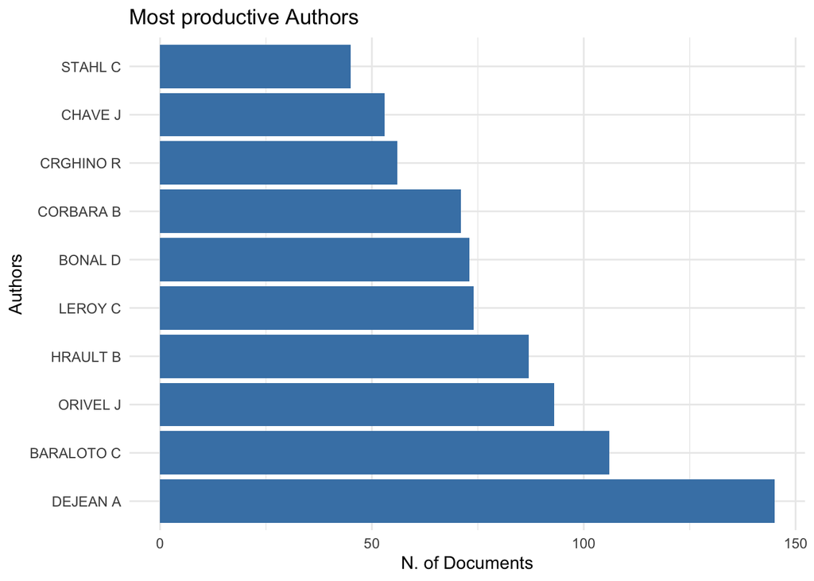

```r
# Graphiques disponibles
BAP$MostProdAuthors
```

```r
BAP$MostProdCountries
```

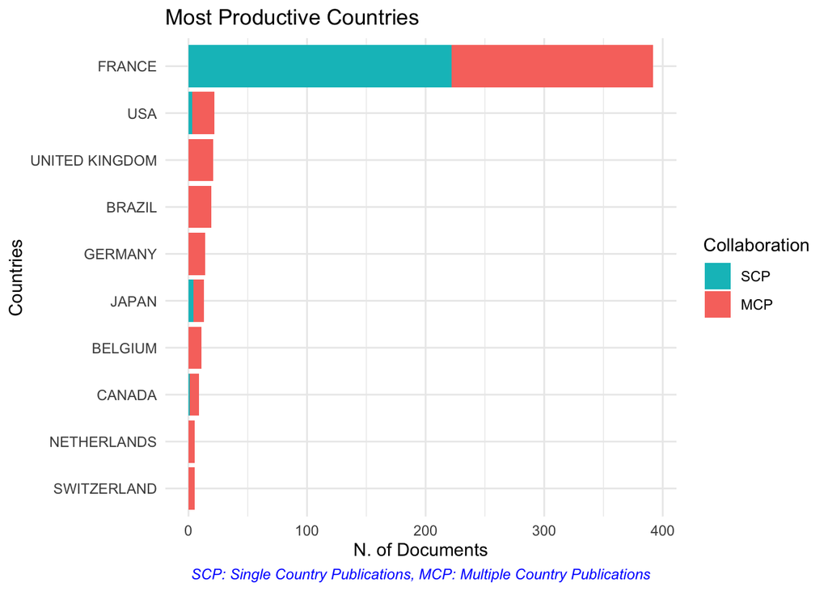

```r
BAP$AnnualScientProd
```

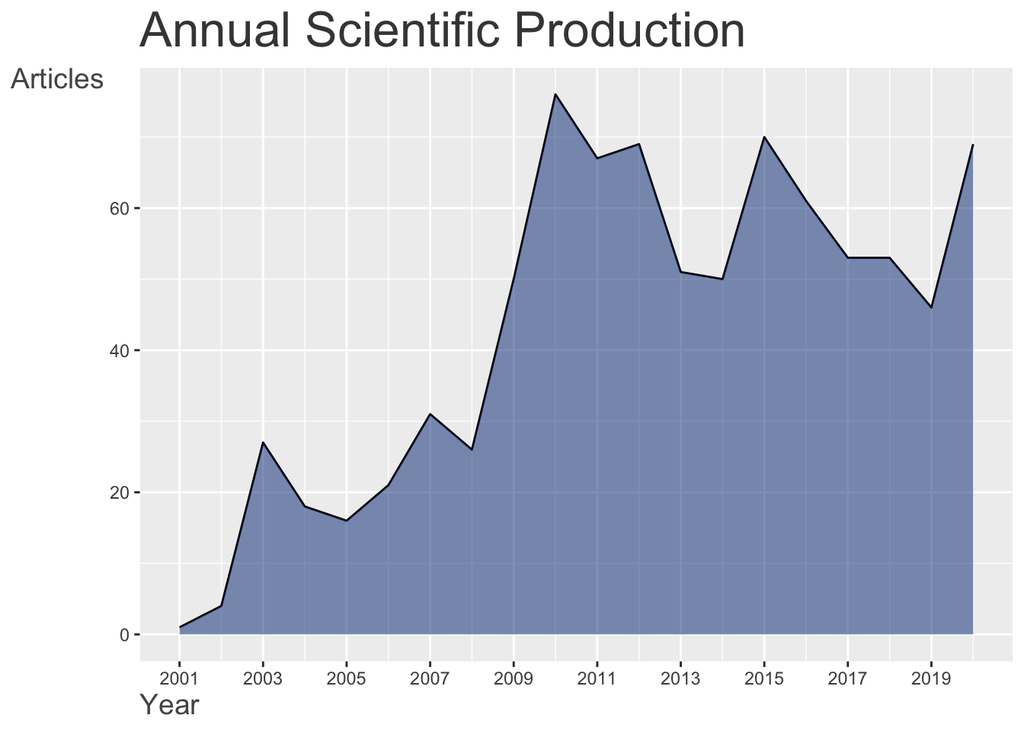

```r
BAP$AverArtCitperYear
```

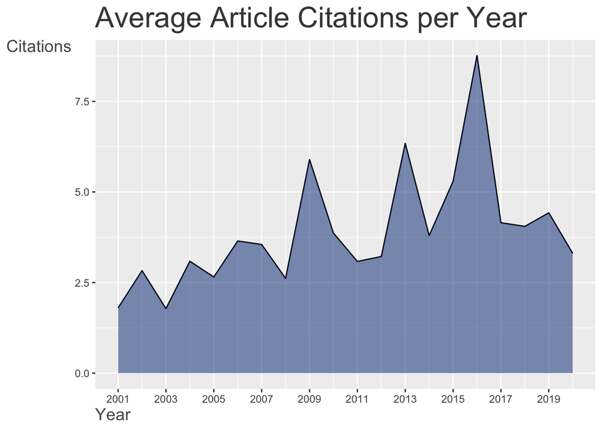

```r
BAP$AverTotCitperYear
```

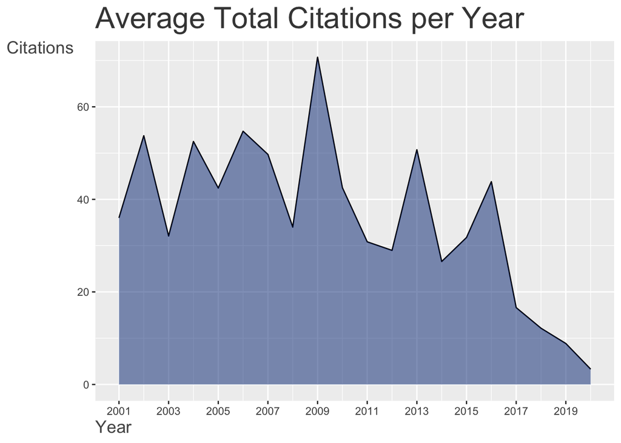

## 2.3 h index

L’indice h peut être calculé par auteur ou source, et depuis un nombre d’années choisi.

Pour tous les auteurs :

```r
Hindex(M, elements = dominance(BA)$Author, years=50)$H %>%
  arrange(desc(h_index))
```

```
##        Author h_index g_index  m_index   TC  NP PY_start
## 1  BARALOTO C      46      89 2.421053 7996 106     2003
## 2     BONAL D      36      73 1.714286 5829  73     2001
## 3     CHAVE J      32      53 1.684211 5813  53     2003
## 4    HRAULT B      31      58 2.066667 3578  87     2007
## 5    DEJEAN A      25      39 1.315789 2347 144     2003
## 6    ORIVEL J      23      35 1.533333 1632  93     2007
## 7     LEROY C      20      28 1.052632 1030  74     2003
## 8   CORBARA B      20      32 1.052632 1194  71     2003
## 9   CRGHINO R      18      25 1.285714  789  56     2008
## 10    STAHL C      16      30 1.333333  951  45     2010
```

Pour l’indice de toute la base bibliographique :

```r
(h <- Hindex(M, elements="*", years=50)$H)
```

```
##   Author h_index g_index  m_index    TC  NP PY_start
## 1      *      77     132 3.666667 28116 859     2001
```

Le graphique rang-citations peut être tracé par le package entropart.

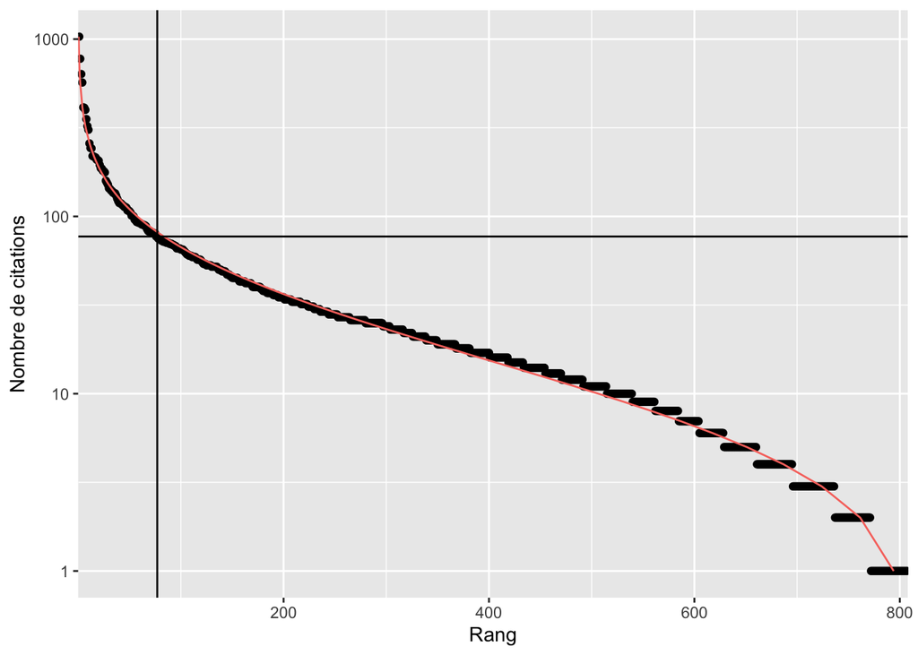

```r
library("entropart")
# Courbe rang-abondance, ajustée à une distribution log-normale
autoplot(as.AbdVector(M$TC), ylab = "Nombre de citations", xlab = "Rang", Distribution = "lnorm") +
# Ajout de l'indice h
  geom_hline(yintercept = h$h_index) +
  geom_vline(xintercept = h$h_index)
```

## 2.4 Documents et auteurs cités

Les documents les plus cités par la base bibliographique sont retournés par la commande `citations`, par article ou par auteur.

```r
CAR <- citations(M, field = "article")
CAR$Cited[1:5] %>%
  as_tibble %>%
  rename(Article = CR, Citations=n) %>%
  knitr::kable(caption =
      "Citations les plus fréquentes par les documents de la base de données bibliographique",
      longtable = TRUE, booktabs = TRUE) %>%
  kableExtra::kable_styling(full_width=TRUE, bootstrap_options = "striped")
```

Table 2.1: Citations les plus fréquentes par les documents de la base de données bibliographique

| Article | Citations |
| --- | --- |
| KRAFT, N.J.B., VALENCIA, R., ACKERLY, D.D., FUNCTIONAL TRAITS AND NICHE-BASED TREE COMMUNITY ASSEMBLY IN AN AMAZONIAN FOREST (2008) SCIENCE, 322, PP. 580-582 | 18 |
| CHAVE, J., COOMES, D., JANSEN, S., LEWIS, S.L., SWENSON, N.G., ZANNE, A.E., TOWARDS A WORLDWIDE WOOD ECONOMICS SPECTRUM (2009) ECOLOGY LETTERS, 12, PP. 351-366 | 16 |
| CRGHINO, R., LEROY, C., DEJEAN, A., CORBARA, B., ANTS MEDIATE THE STRUCTURE OF PHYTOTELM COMMUNITIES IN AN ANT-GARDEN BROMELIAD (2010) ECOLOGY, 91, PP. 1549-1556 | 13 |
| FINE, P.V.A., MESONES, I., COLEY, P.D., HERBIVORES PROMOTE HABITAT SPECIALIZATION BY TREES IN AMAZONIAN FORESTS (2004) SCIENCE, 305, PP. 663-665 | 13 |
| NEPSTAD, D.C., TOHVER, I.M., RAY, D., MOUTINHO, P., CARDINOT, G., MORTALITY OF LARGE TREES AND LIANAS FOLLOWING EXPERIMENTAL DROUGHT IN AN AMAZON FOREST (2007) ECOLOGY, 88, PP. 2259-2269 | 13 |

Les auteurs les plus cités :

```r
CAU <- citations(M, field = "author")
CAU$Cited[1:5] %>%
  as_tibble %>%
  rename(Auteur=CR, Citations=n) %>%
  knitr::kable(
    caption="Auteurs les plus cités par les documents de la base de données bibliographique",
    longtable = TRUE, booktabs = TRUE) %>%
  kableExtra::kable_styling(bootstrap_options = "striped")
```

Table 2.2: Auteurs les plus cités par les documents de la base de données bibliographique

| Auteur | Citations |
| --- | --- |
| DEJEAN A | 927 |
| BARALOTO C | 522 |
| ORIVEL J | 495 |
| BONAL D | 492 |
| CHAVE J | 442 |

## 2.5 Collaborations

Un réseau de collaboration entre les pays des auteurs est retourné par la fonction `biblioNetwork`.

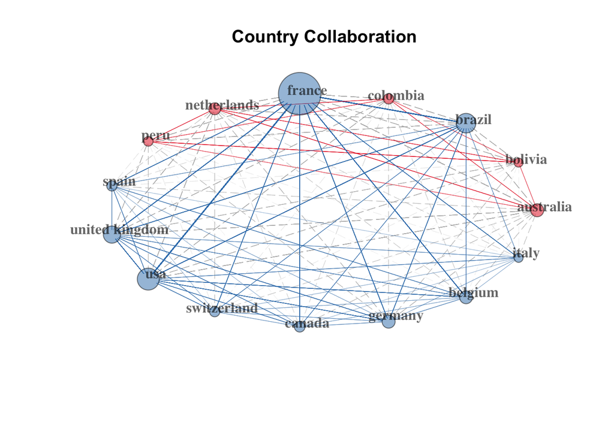

```r
NbCountries <- 15
# Create a country collaboration network
mAU_CO <- metaTagExtraction(M, Field = "AU_CO", sep = ";")
NetMatrix <- biblioNetwork(mAU_CO, analysis = "collaboration",
    network = "countries", sep = ";")
# Plot the network
netC <- networkPlot(NetMatrix, n = NbCountries, Title = "Country Collaboration",
    type = "circle", size = TRUE, remove.multiple = FALSE)
```

Le réseau des auteurs est obtenu de la même façon.

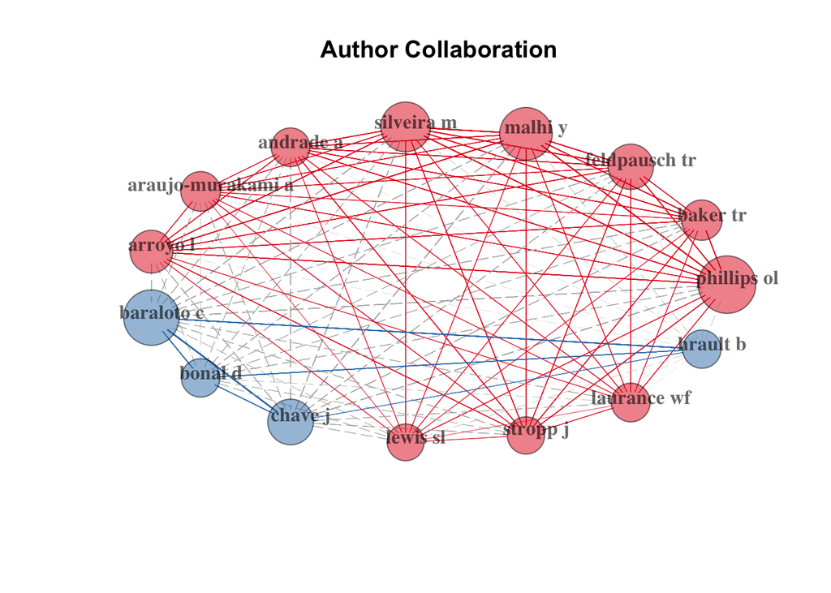

```r
NbAuthors <- 15
# Réseau d'auteurs
AuthorNet <- biblioNetwork(M, analysis = "collaboration",
    network = "authors", sep = ";")
netA <- networkPlot(AuthorNet, n = NbAuthors, Title = "Author Collaboration",
    type = "circle", size = TRUE, remove.multiple = FALSE)
```

# 3 Analyse des résumés

Les résumés des publications se trouvent dans la colonne `AB` de la base importée par *bibliometrix*. Ils sont en Anglais.

## 3.1 Corpus

Le package `tm` permet de constituer un corpus.

```r
library("tm")
M$AB %>%
  VectorSource %>%
  VCorpus %>%
  tm_map(PlainTextDocument) %>%
  tm_map(content_transformer(tolower)) ->
  MonCorpus
```

## 3.2 Nettoyage du corpus

Des mots sémantiquement identiques ont plusieurs formes. Le traitement le plus rigoureux consiste à les réduire à leur radical mais le résultat n’est pas très lisible. La fonction `stemDocument` permet de le faire : il suffit de l’utiliser à la place de `PlainTextDocument` dans le code ci-dessus. Un bon compromis consiste à supprimer les formes plurielles, par une fonction ad-hoc : ce sera fait plus tard.

```r
MonCorpus %<>% tm_map(removePunctuation) %>%
  tm_map(removeNumbers) %>%
  tm_map(removeWords, stopwords("english"))
```

Une liste de mots complémentaire est nécessaire pour supprimer des mots inutiles mais fréquents. Elle peut être complétée de façon itérative pour retirer des mots parasites du résultat final.

```r
ExtraWords <- c("use", "used", "using", "results",
    "may", "across", "high", "higher", "low", "show",
    "showed", "study", "studies", "studied", "however",
    "can", "our", "based", "including", "within", "total",
    "among", "found", "due", "also", "well", "strong",
    "large", "important", "first", "known", "one",
    "two", "three")
MonCorpus %<>% tm_map(removeWords, ExtraWords)
```

## 3.3 Mots du corpus

L’objectif est de transformer le corpus en un vecteur d’abondance des mots utilisés. `TermDocumentMatrix` crée un objet spécifique au package *tm* qui pose des problèmes de traitement. Cet objet est transformé en un vecteur d’abondances.

```r
TDM <- TermDocumentMatrix(MonCorpus, control = list(minWordLength = 3))
AbdMots <- sort(rowSums(as.matrix(TDM)), decreasing = TRUE)
```

Le vecteur de mots contient des formes singulières et plurielles. Elles peuvent être regroupées selon un modèle simple : si un mot existe avec et sans *s* ou *es* final, la forme singulière est sans *s* ou *es*. Des pluriels particuliers peuvent être ajoutés selon les besoins.

```r
# Adapté de https://github.com/mkfs/misc-text-mining/blob/master/R/wordcloud.R
aggregate_plurals <- function (v) {
    aggr_fn <- function(v, singular, plural) {
        if (! is.na(v[plural])) {
            v[singular] <- v[singular] + v[plural]
            v <- v[-which(names(v) == plural)]
        }
        return(v)
    }
    for (n in names(v)) {
        n_pl <- paste(n, 's', sep='')
        v <- aggr_fn(v, n, n_pl)
        n_pl <- paste(n, 'es', sep='')
        v <- aggr_fn(v, n, n_pl)
        # cas particuliers
        if (endsWith(n, "y")) {
          n <-  substr(n, 1, nchar(n)-1)
          n_pl <- paste(n, 'ies', sep='')
          }
        if (n == "genus") {
          n_pl <- "genera"
          v <- aggr_fn(v, n, n_pl)
        }
    }
    return(v)
}

AbdMots %<>% aggregate_plurals
```

## 3.4 Nuage de mots

Le résultat final est un nuage de mots.

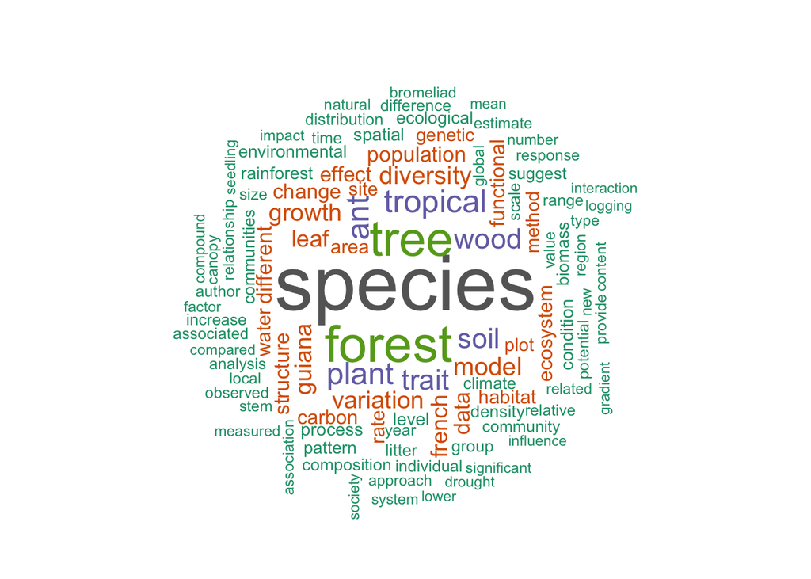

```r
library("wordcloud")
df <- data.frame(word = names(AbdMots), freq = AbdMots)
wordcloud(df$word, df$freq, max.words = 100, random.order = FALSE,
    rot.per = 0.35, use.r.layout = FALSE, colors = brewer.pal(8,
        "Dark2"))
```